# Correlaciones entre variables del Censo de Viviendas, Hogares y Personas e ingresos promedios comunales de la CASEN 2017.

VE-CC-AJ

DataIntelligence

Jueves 01-06-2021

Abstract

Calculamos correlaciones entre el ingreso promedio comunal **multiplicado por la población comunal** que llamaremos **ingresos expandidos** extraído de la Casen 2017 y las frecuencias de categorías de respuesta para todas las variables del Censo de viviendas, hogares y personas al 2017, también extraídas a nivel comunal.

Haremos las correlaciones tanto a nivel Urbano como rural.

Importante es aplicar la libreria **dplyr** para evitar que en los filtros se desplieguen series de tiempo.

# 2 Pregunta **P15**: Nivel del curso más alto aprobado, nivel Urbano

Area: urbano = 1 rural = 2

1 Sala cuna o jardín infantil  
2 Prekínder  
3 Kínder  
4 Especial o diferencial  
5 Educación básica  
6 Primaria o preparatorio (sistema antiguo)  
7 Científico-humanista  
8 Técnica profesional  
9 Humanidades (sistema antiguo)  
10 Técnica comercial, industrial/normalista (sistema antiguo)  
11 Técnico superior (1-3 años)  
12 Profesional (4 o más años)  
13 Magíster  
14 Doctorado  
98 No aplica  
99 Missing

### 2.3.1 Cálculo de frecuencias

Leemos las respuestas a la pregunta P15 del censo de **personas** 2017 y obtenemos la tabla de frecuencias por categoría de respuesta:

```r
tabla_con_clave <- readRDS("../censo_personas_con_clave_17")
tabla_con_clave <- filter(tabla_con_clave, tabla_con_clave$AREA == 1)
```

```r
b <- tabla_con_clave$COMUNA
c <- tabla_con_clave$P15
cross_tab =  xtabs( ~ unlist(b) + unlist(c))
tabla <- as.data.frame(cross_tab)
d <-tabla[!(tabla$Freq == 0),]
d$anio <- "2017"
```

```r
d_t <- filter(d,d$unlist.c. == 1)
for(i in 2:14){
  d_i <- filter(d,d$unlist.c. == i)
  d_t = merge( x = d_t, y = d_i, by = "unlist.b.", all.x = TRUE)
}

codigos <- d_t$unlist.b.
rango <- seq(1:nrow(d_t))
cadena <- paste("0",codigos[rango], sep = "")
cadena <- substr(cadena,(nchar(cadena)[rango])-(4),6)
codigos <- as.data.frame(codigos)
cadena <- as.data.frame(cadena)
comuna_corr <- cbind(d_t,cadena)
comuna_corr <- comuna_corr[,-c(1),drop=FALSE]

names(comuna_corr)[43] <- "código"

ingresos_expandidos_2017 <- readRDS("Ingresos_expandidos_urbano_17.rds")

df_2017_2 = merge( x = comuna_corr, y = ingresos_expandidos_2017, by = "código", all.x = TRUE)
```

### 2.3.4 Renombre de columnas

```r
names(df_2017_2)[3] <- "Sala cuna"
names(df_2017_2)[6] <- "Prekínder"
names(df_2017_2)[9] <- "Kínder"
names(df_2017_2)[12] <- "Especial"
names(df_2017_2)[15] <- "Educación básica"
names(df_2017_2)[18] <- "Primaria"
names(df_2017_2)[21] <- "Científico-humanista"
names(df_2017_2)[24] <- "Técnica profesional"
names(df_2017_2)[27] <- "Humanidades"
names(df_2017_2)[30] <- "Técnica comercial"
names(df_2017_2)[33] <- "Técnico superior "
names(df_2017_2)[36] <- "Profesional"
names(df_2017_2)[39] <- "Magíster"
names(df_2017_2)[42] <- "Doctorado"
```

### 2.3.5 **Correlaciones**

#### 2.3.5.1 Pearson

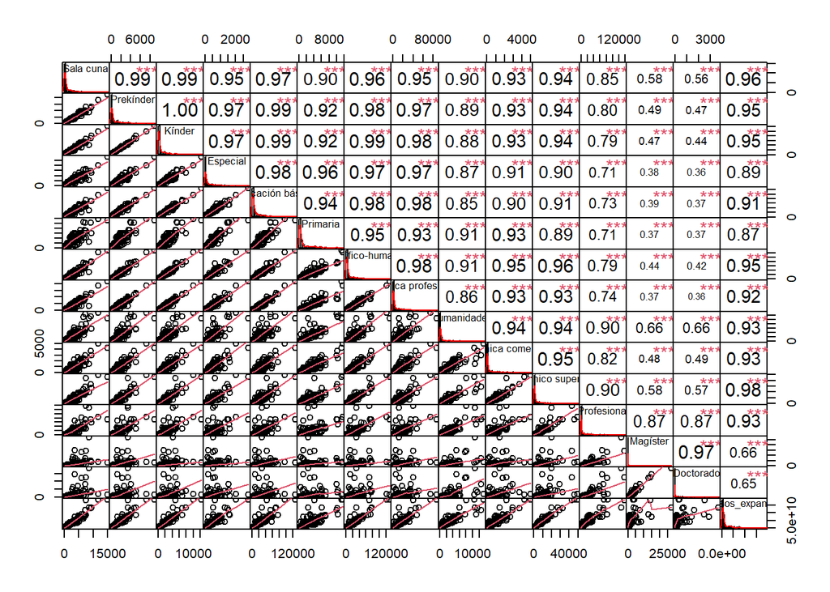

```r
my_data <- df_2017_2[, c(3,6,9,12,15,18,21,24,27,30,33,36,39,42,48)]
chart.Correlation(my_data, histogram=TRUE, method = c( "pearson"), pch=20)
```

#### 2.3.5.2 Spearman

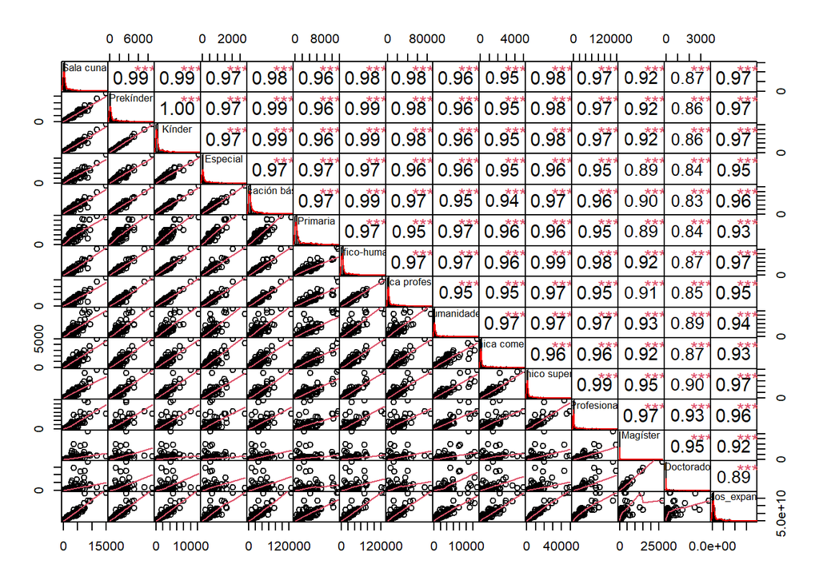

```r
chart.Correlation(my_data, histogram=TRUE, method = c( "spearman"), pch=20)
```

#### 2.3.5.3 Kendall

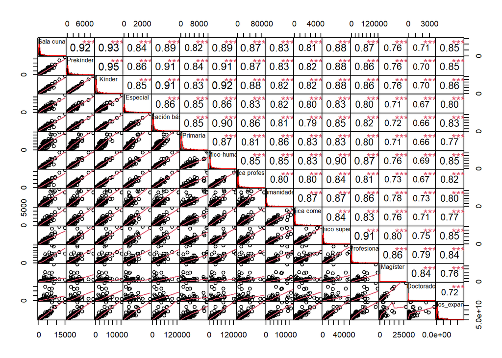

```r
chart.Correlation(my_data, histogram=TRUE, method = c( "kendall"), pch=20)
```

# 1 Pregunta **P15**: Nivel del curso más alto aprobado, nivel Rural

Area: urbano = 1 rural = 2

1 Sala cuna o jardín infantil  
2 Prekínder  
3 Kínder  
4 Especial o diferencial  
5 Educación básica  
6 Primaria o preparatorio (sistema antiguo)  
7 Científico-humanista  
8 Técnica profesional  
9 Humanidades (sistema antiguo)  
10 Técnica comercial, industrial/normalista (sistema antiguo)  
11 Técnico superior (1-3 años)  
12 Profesional (4 o más años)  
13 Magíster  
14 Doctorado  
98 No aplica  
99 Missing

### 2.3.1 Cálculo de frecuencias

Leemos las respuestas a la pregunta P15 del censo de **personas** 2017 y obtenemos la tabla de frecuencias por categoría de respuesta:

```r
tabla_con_clave <- readRDS("../censo_personas_con_clave_17")
tabla_con_clave <- filter(tabla_con_clave, tabla_con_clave$AREA == 2)
```

```r
b <- tabla_con_clave$COMUNA
c <- tabla_con_clave$P15
cross_tab =  xtabs( ~ unlist(b) + unlist(c))
tabla <- as.data.frame(cross_tab)
d <-tabla[!(tabla$Freq == 0),]
d$anio <- "2017"
```

```r
d_t <- filter(d,d$unlist.c. == 1)
for(i in 2:14){
  d_i <- filter(d,d$unlist.c. == i)
  d_t = merge( x = d_t, y = d_i, by = "unlist.b.", all.x = TRUE)
}

codigos <- d_t$unlist.b.
rango <- seq(1:nrow(d_t))
cadena <- paste("0",codigos[rango], sep = "")
cadena <- substr(cadena,(nchar(cadena)[rango])-(4),6)
codigos <- as.data.frame(codigos)
cadena <- as.data.frame(cadena)
comuna_corr <- cbind(d_t,cadena)
comuna_corr <- comuna_corr[,-c(1),drop=FALSE]

names(comuna_corr)[43] <- "código"

ingresos_expandidos_2017 <- readRDS("Ingresos_expandidos_rural_17.rds")

df_2017_2 = merge( x = comuna_corr, y = ingresos_expandidos_2017, by = "código", all.x = TRUE)
```

### 2.3.4 Renombre de columnas

```r
names(df_2017_2)[3] <- "Sala cuna"
names(df_2017_2)[6] <- "Prekínder"
names(df_2017_2)[9] <- "Kínder"
names(df_2017_2)[12] <- "Especial"
names(df_2017_2)[15] <- "Educación básica"
names(df_2017_2)[18] <- "Primaria"
names(df_2017_2)[21] <- "Científico-humanista"
names(df_2017_2)[24] <- "Técnica profesional"
names(df_2017_2)[27] <- "Humanidades"
names(df_2017_2)[30] <- "Técnica comercial"
names(df_2017_2)[33] <- "Técnico superior "
names(df_2017_2)[36] <- "Profesional"
names(df_2017_2)[39] <- "Magíster"
names(df_2017_2)[42] <- "Doctorado"
```

### 2.3.5 **Correlaciones**

#### 2.3.5.1 Pearson

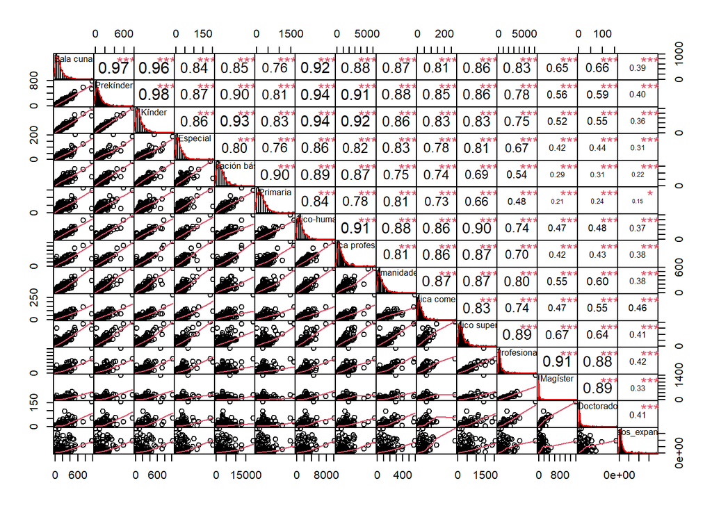

```r
my_data <- df_2017_2[, c(3,6,9,12,15,18,21,24,27,30,33,36,39,42,48)]
chart.Correlation(my_data, histogram=TRUE, method = c( "pearson"), pch=20)
```

#### 2.3.5.2 Spearman

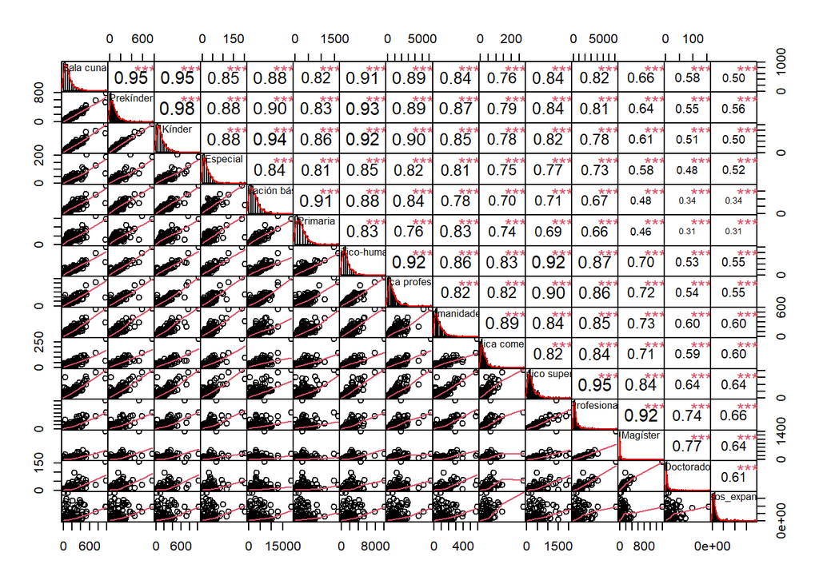

```r
chart.Correlation(my_data, histogram=TRUE, method = c( "spearman"), pch=20)
```

#### 2.3.5.3 Kendall

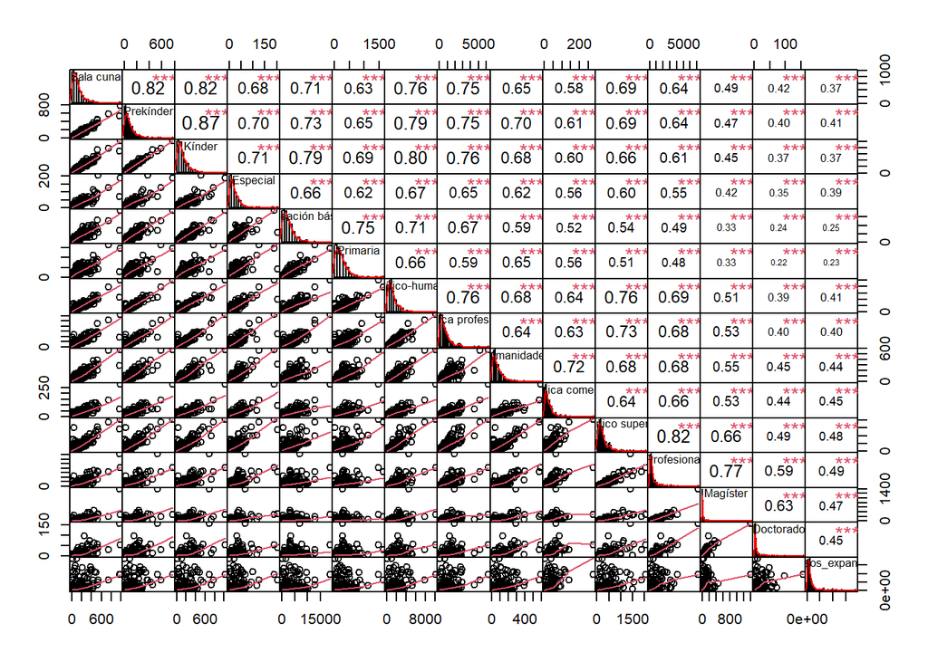

```r
chart.Correlation(my_data, histogram=TRUE, method = c( "kendall"), pch=20)
```